# Bayesian GAM Part1

Author

Murray Logan

Published

23/09/2026

# 1 Preparations

Load the necessary libraries

```r
library(tidyverse)  #for data wrangling etc
library(cmdstanr)   #for cmdstan
library(brms)       #for fitting models in STAN
library(standist)   #for exploring distributions
library(coda)       #for diagnostics
library(bayesplot)  #for diagnostics
library(ggmcmc)     #for MCMC diagnostics
library(DHARMa)     #for residual diagnostics
library(rstan)      #for interfacing with STAN
library(emmeans)    #for marginal means etc
library(broom)      #for tidying outputs
library(tidybayes)  #for more tidying outputs
library(HDInterval) #for HPD intervals
library(ggeffects)  #for partial plots
library(broom.mixed)#for summarising models
library(posterior)  #for posterior draws
library(ggeffects)  #for partial effects plots
library(patchwork)  #for multi-panel figures
library(bayestestR) #for ROPE
library(see)        #for some plots
library(easystats)     #framework for stats, modelling and visualisation
library(mgcv)
library(gratia)
theme_set(theme_grey()) #put the default ggplot theme back
source('helperFunctions.R')
```

# 2 Scenario

This is an entirely fabricated example (how embarrising). So here is a picture of some Red Grouse Chicks to compensate..

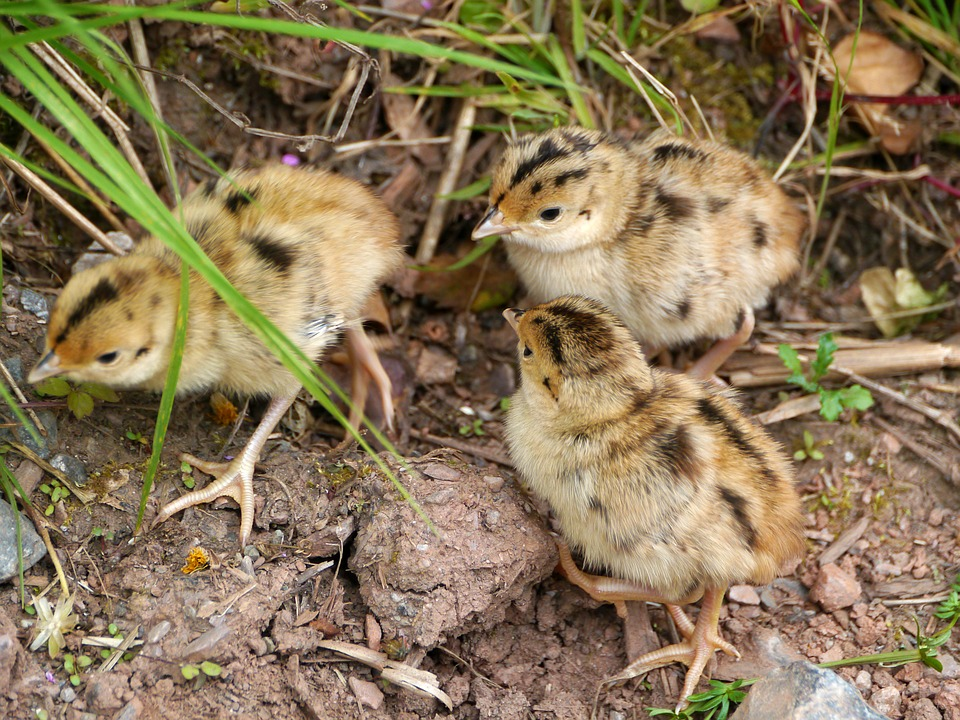

**Figure** 1: Red grouse chicks

**Table** 1: Format of data.gp.csv data file

| x | y |
| --- | --- |
| 2 | 3 |
| 4 | 5 |
| 8 | 6 |
| 10 | 7 |
| 14 | 4 |

**Table** 2: Format of data.gp.csv data file

| **x** | - a continuous predictor |
| --- | --- |
| **y** | - a continuous response |

# 3 Read in the data

```r
data_gam <- read_csv("../data/data_gam.csv", trim_ws = TRUE)
```

**glimpse**

```r
data_gam |> glimpse()
```

```
Rows: 5
Columns: 2
$ x <dbl> 2, 4, 8, 10, 14
$ y <dbl> 3, 5, 6, 7, 4
```

**head**

```r
## Explore the first 6 rows of the data
data_gam |> head()
```

```
# A tibble: 5 × 2
      x     y
  <dbl> <dbl>
1     2     3
2     4     5
3     8     6
4    10     7
5    14     4
```

**str**

```r
data_gam |> str()
```

```
spc_tbl_ [5 × 2] (S3: spec_tbl_df/tbl_df/tbl/data.frame)
 $ x: num [1:5] 2 4 8 10 14
 $ y: num [1:5] 3 5 6 7 4
 - attr(*, "spec")=
  .. cols(
  ..   x = col_double(),
  ..   y = col_double()
  .. )
 - attr(*, "problems")=<externalptr>
```

**Easystats (datawizard)**

```r
data_gam |> datawizard::data_codebook()
```

```
data_gam (5 rows and 2 variables, 2 shown)

ID | Name | Type    | Missings | Values |         N
---+------+---------+----------+--------+----------
1  | x    | numeric | 0 (0.0%) |      2 | 1 (20.0%)
   |      |         |          |      4 | 1 (20.0%)
   |      |         |          |      8 | 1 (20.0%)
   |      |         |          |     10 | 1 (20.0%)
   |      |         |          |     14 | 1 (20.0%)
---+------+---------+----------+--------+----------
2  | y    | numeric | 0 (0.0%) |      3 | 1 (20.0%)
   |      |         |          |      4 | 1 (20.0%)
   |      |         |          |      5 | 1 (20.0%)
   |      |         |          |      6 | 1 (20.0%)
   |      |         |          |      7 | 1 (20.0%)
---------------------------------------------------
```

# 4 Exploratory data analysis

Model formula:
$$\begin{align}
y_i &\sim{} \mathcal{N}(\mu_i, \sigma^2)\\
\mu_i &=\beta_0 + f(x_i)\\
f(x_i) &= \sum^k_{j=1}{b_j(x_i)\beta_j}
\end{align}$$

where $\beta_0$ is the y-intercept, and $f(x)$ indicates an additive smoothing function of $x$.

Although this is a ficticious example without a clear backstory, given that there are two continous predictors (and that one of these has been identified as a response and the other a predictor), we can assume that we might be interested in investigating the relationship between the two. As such, our typically starting point is to explore the basic trend between the two using a scatterplot.

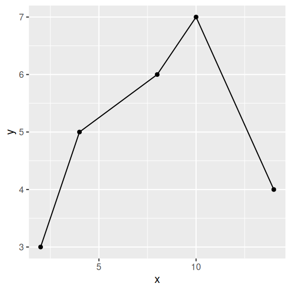

```r
ggplot(data_gam, aes(y=y, x=x))+
    geom_point()+
    geom_line()
```

This does not look like a particularly linear relationship. Lets fit a loess smoother..

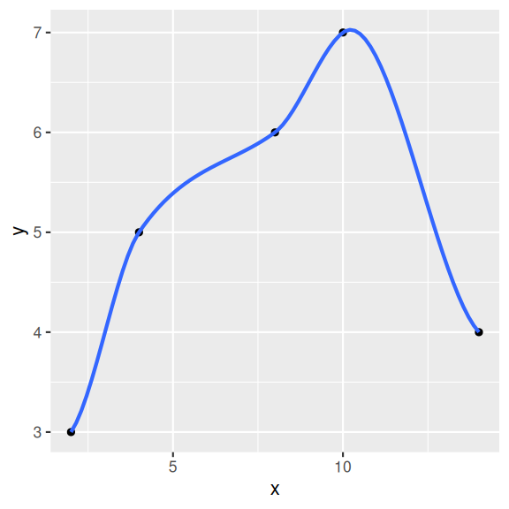

```r
ggplot(data_gam, aes(y=y, x=x))+
    geom_point()+
    geom_smooth()
```

And what would a linear smoother look like?

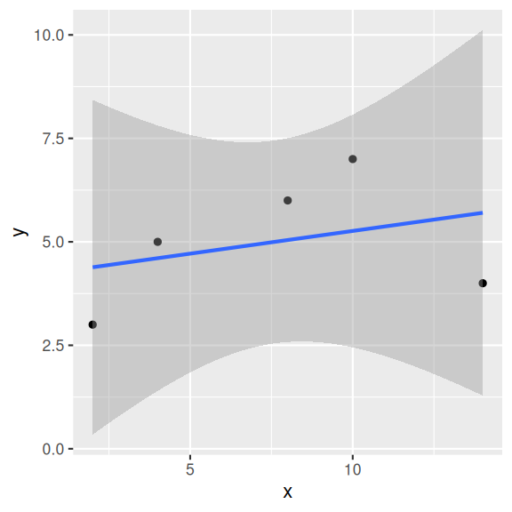

```r
ggplot(data_gam, aes(y=y, x=x))+
    geom_point()+
    geom_smooth(method='lm')
```

Rather than either a loess or linear smoother, we can also try a Generalized Additive Model (GAM) smoother. Dont pay too much attention to the GAM formula at this stage, this will be discussed later in the Model Fitting section.

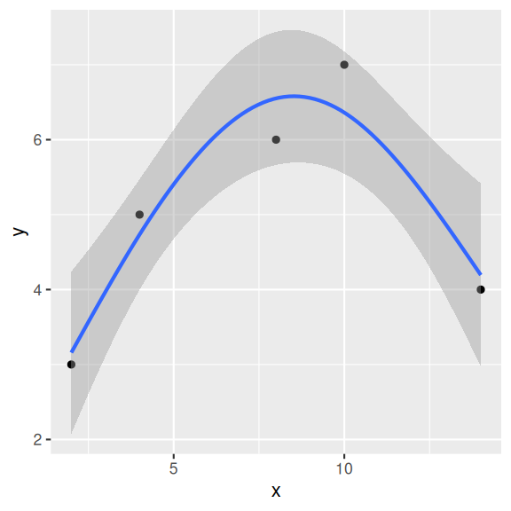

```r
ggplot(data_gam, aes(y=y, x=x))+
    geom_point()+
    geom_smooth(method='gam', formula=y~s(x,k=3))
```

**Conclusions:**

- it is clear that the relationship is not linear.
- it does appear that as x inreases, y initially increases before eventually declining again.
- we could model this with a polynomial, but for this exemple, we will use these data to illustrate the fitting of GAMs.

# 5 Fit the model

**basis functions**

Prior to fitting the GAM, it might be worth gaining a bit of an understanding of what will occur behind the scenes.

Lets say we intended to fit a smoother with three knots. The three knots equate to one at each end of the trend and one in the middle. We could reexpress our predictor (x) as three dummy variables that collectively reflect a spline (in this case, potentially two joined polynomials).

```r
data.frame(mgcv::smoothCon(s(x, k=3),  data=data_gam)[[1]]$X) %>%
  bind_cols(data_gam)
```

```
         X1 X2          X3  x y
1 1.3554342  1 -1.31122014  2 3
2 0.9289363  1 -0.84292723  4 5
3 0.4755086  1  0.09365858  8 6
4 0.5780165  1  0.56195149 10 7
5 1.3189632  1  1.49853730 14 4
```

And we could visualize these dummies as three separate components.

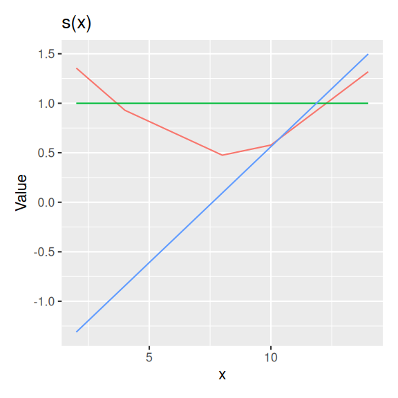

```r
basis(s(x, k=3),  data=data_gam) %>% draw()
```

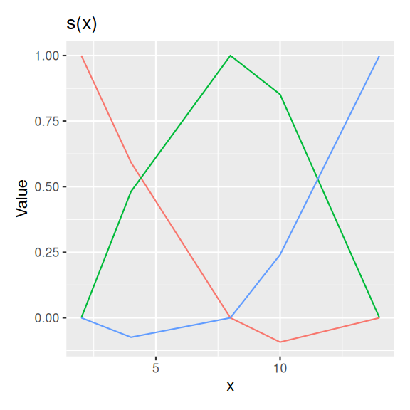

```r
basis(s(x, k=3, bs='cr'),  data=data_gam) %>% draw()
```

OR

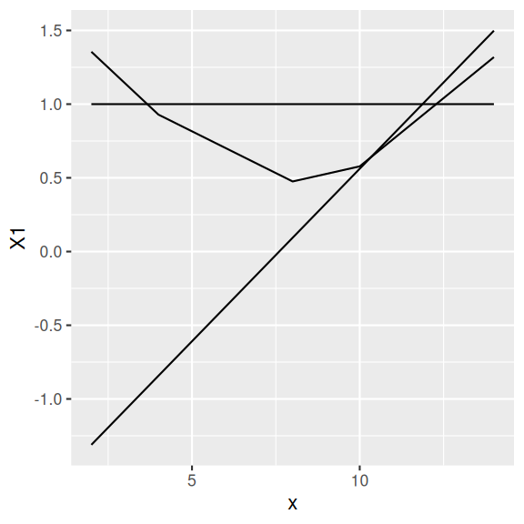

```r
newdata <-
    data.frame(smoothCon(s(x, k=3),  data=data_gam)[[1]]$X) %>%
    bind_cols(data_gam)
ggplot(newdata,  aes(x=x)) +
    geom_line(aes(y=X1)) +
    geom_line(aes(y=X2)) +
    geom_line(aes(y=X3))
```

**brms**

brms follows the same basic process as `gamm4`. That is the smooths are partitioned into two components:

- a penalised component which is treated as a random effect
- an unpenalised component that is treated as a fixed effect

The wiggliness penalty matrix is the precision matrix when the smooth is treated as a random effect The smoothness of a term is determined by estimating the variance of the term

**Using default priors**

In `brms`, the default priors are designed to be weakly informative. They are chosen to provide moderate regularisation (to help prevent over-fitting) and help stabilise the computations.

Unlike `rstanarm`, `brms` models must be compiled before they start sampling. For most models, the compilation of the stan code takes around 45 seconds.

```r
data_gam_form <- bf(y ~ s(x), family = gaussian())
data_gam.brm <- brm(data_gam_form,
               data = data_gam,
               iter = 5000,
               warmup = 1000,
               chains = 3,
               thin = 5,
               refresh = 0,
               backend = "rstan")
```

```
Error in `smooth.construct.tp.smooth.spec()`:
! A term has fewer unique covariate combinations than specified maximum degrees of freedom
```

```r
data_gam_form <- bf(y ~ s(x, k = 3), family = gaussian())
get_prior(data_gam_form, data =  data_gam)
```

```
                prior     class        coef group resp dpar nlpar lb ub tag
               (flat)         b
               (flat)         b        sx_1
 student_t(3, 5, 2.5) Intercept
 student_t(3, 0, 2.5)       sds                                    0
 student_t(3, 0, 2.5)       sds s(x, k = 3)                        0
 student_t(3, 0, 2.5)     sigma                                    0
       source
      default
 (vectorized)
      default
      default
 (vectorized)
      default
```

```r
data_gam.brm <- brm(data_gam_form,
               data = data_gam,
               iter = 5000,
               warmup = 1000,
               chains = 3, cores = 3,
               thin = 5,
               refresh = 0,
               backend = "rstan")
```

```r
prior_summary(data_gam.brm)
```

```
                prior     class        coef group resp dpar nlpar lb ub tag       source
               (flat)         b                                                  default
               (flat)         b        sx_1                                 (vectorized)
 student_t(3, 5, 2.5) Intercept                                                  default
 student_t(3, 0, 2.5)       sds                                    0             default
 student_t(3, 0, 2.5)       sds s(x, k = 3)                        0        (vectorized)
 student_t(3, 0, 2.5)     sigma                                    0             default
```

sds - standard devation of the wiggly basis function

**Assessing priors**

```r
data_gam.brm <- brm(data_gam_form,
                 data = data_gam,
                 prior = prior(normal(0, 2.5), class = 'b'),
                 sample_prior = 'only',
                 iter = 5000,
                 warmup = 1000,
                 chains = 3,
                 thin = 5,
                 backend = "rstan",
                 refresh = 0)
```

#### conditional_effects

```
Ignoring unknown labels:
• fill : "NA"
• colour : "NA"
Ignoring unknown labels:
• fill : "NA"
• colour : "NA"
```

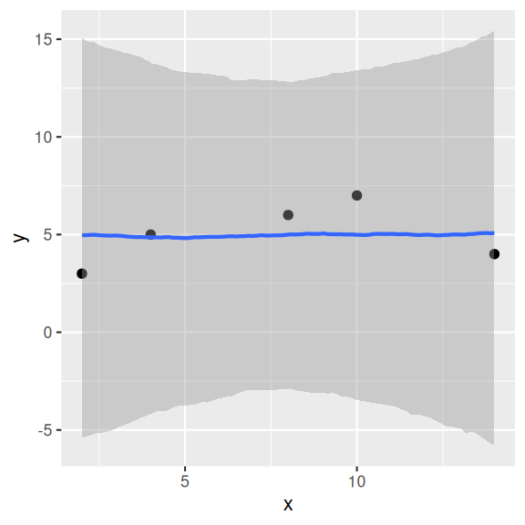

```r
data_gam.brm |> conditional_effects() |>  plot(points=TRUE)
```

**Defining priors**

The following link provides some guidance about defining priors. [https://github.com/stan-dev/stan/wiki/Prior-Choice-Recommendations]

When defining our own priors, we typically do not want them to be scaled.

If we wanted to define our own priors that were less vague, yet still not likely to bias the outcomes, we could try the following priors (which I have mainly plucked out of thin air):

#### Sample prior only

I will also overlay the raw data for comparison.

```r
data_gam_form <- bf(y ~ s(x), family = gaussian())
## get_prior(data_gam_form, data = data_gam)
data_gam_form <- bf(y ~ s(x, k = 3), family = gaussian())
get_prior(data_gam_form, data = data_gam)
```

```
                prior     class        coef group resp dpar nlpar lb ub tag
               (flat)         b
               (flat)         b        sx_1
 student_t(3, 5, 2.5) Intercept
 student_t(3, 0, 2.5)       sds                                    0
 student_t(3, 0, 2.5)       sds s(x, k = 3)                        0
 student_t(3, 0, 2.5)     sigma                                    0
       source
      default
 (vectorized)
      default
      default
 (vectorized)
      default
```

```r
data_gam |>
  summarise(
    median = median(y),
    mad = mad(y)
    )
```

```
# A tibble: 1 × 2
  median   mad
   <dbl> <dbl>
1      5  1.48
```

```r
priors <- prior(normal(5, 1.5),  class='Intercept') +
  prior(normal(0, 1.5), class='b') +
  prior(student_t(3, 0, 1.5),  class='sigma') +
  prior(student_t(3, 0, 10), class =  "sds")

data_gam_brm1 <- brm(data_gam_form,
  data = data_gam,
  prior = priors,
  sample_prior = 'only',
  iter = 5000,
  warmup = 1000,
  chains = 3, cores =  3,
  thin = 5,
  backend = "rstan",
  control =  list(adapt_delta =  0.99),
  seed = 123,
  refresh = 0)
```

```
Ignoring unknown labels:
• fill : "NA"
• colour : "NA"
Ignoring unknown labels:
• fill : "NA"
• colour : "NA"
```

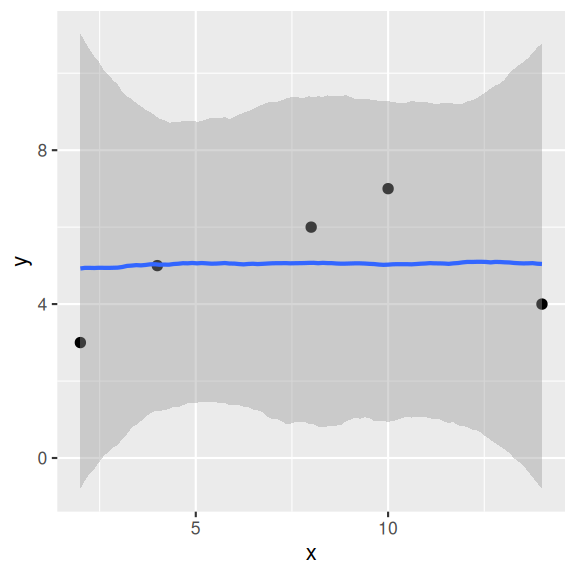

```r
data_gam_brm1 |> conditional_effects() |>  plot(points=TRUE)
```

```
Ignoring unknown labels:
• fill : "NA"
• colour : "NA"
Ignoring unknown labels:
• fill : "NA"
• colour : "NA"
```

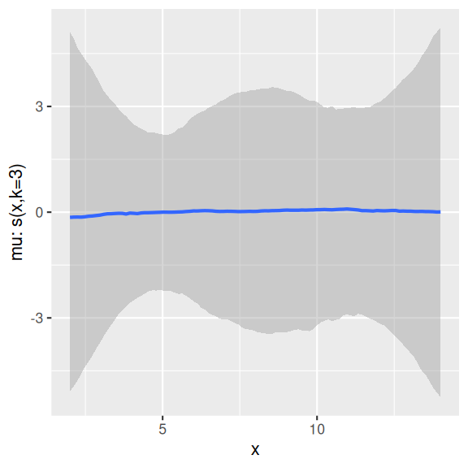

```r
data_gam_brm1 |> conditional_smooths() |>  plot()
```

#### Sample prior and posterior

```r
data_gam_brm2 <- update(data_gam_brm1,
  sample_prior = "yes",
  cores = 3, refresh = 0,
  seed = 123
)
```

```
The desired updates require recompiling the model
```

```
Ignoring unknown labels:
• fill : "NA"
• colour : "NA"
Ignoring unknown labels:
• fill : "NA"
• colour : "NA"
```

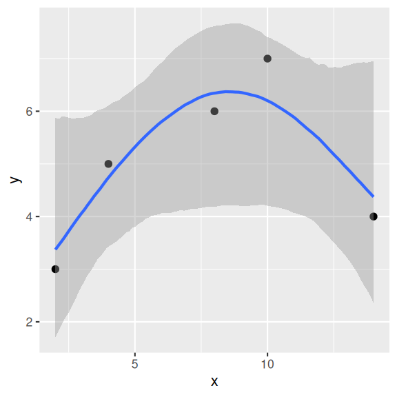

```r
data_gam_brm2 |> conditional_effects() |>  plot(points=TRUE)
```

```
Ignoring unknown labels:
• colour : "NA"
Ignoring unknown labels:
• colour : "NA"
```

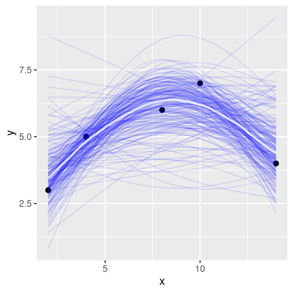

```r
data_gam_brm2 |> conditional_effects(spaghetti = TRUE, ndraws =  200) |>  plot(points=TRUE)
```

**Plotting prior and posterior**

```r
data_gam_brm2 |> get_variables()
```

```
 [1] "b_Intercept"     "bs_sx_1"         "sds_sx_1"        "sigma"
 [5] "Intercept"       "s_sx_1[1]"       "prior_Intercept" "prior_bs"
 [9] "prior_sds_sx"    "prior_sigma"     "lprior"          "lp__"
[13] "accept_stat__"   "stepsize__"      "treedepth__"     "n_leapfrog__"
[17] "divergent__"     "energy__"
```

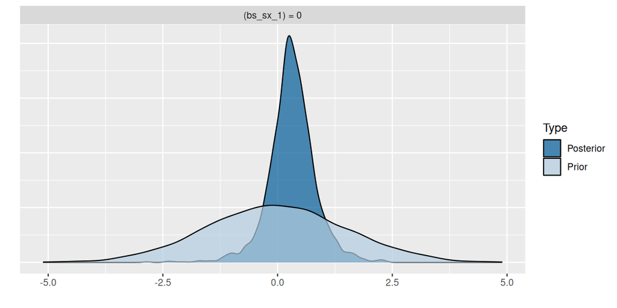

```r
data_gam_brm2 |> hypothesis('bs_sx_1 = 0', class = '') |> plot()
```

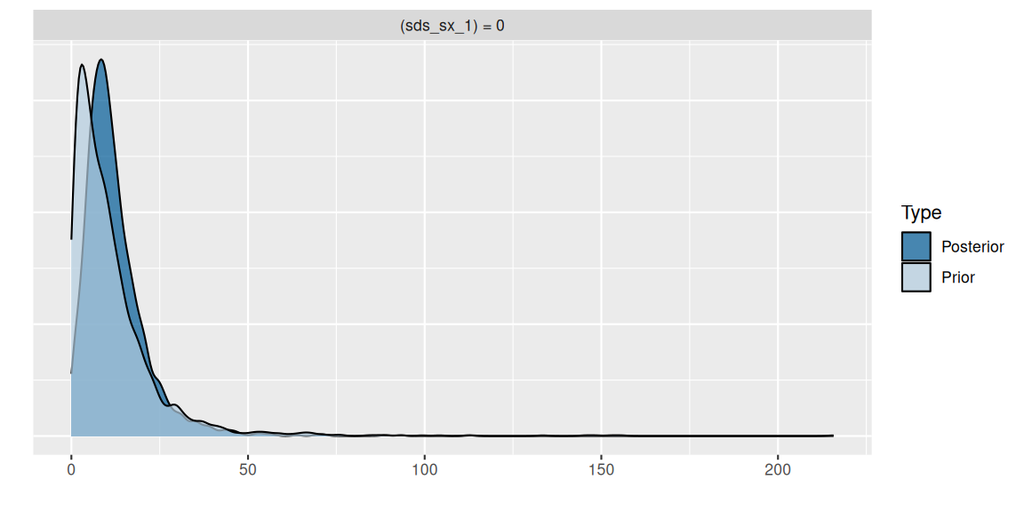

```r
data_gam_brm2 |> hypothesis('sds_sx_1 = 0', class = '') |> plot()
```

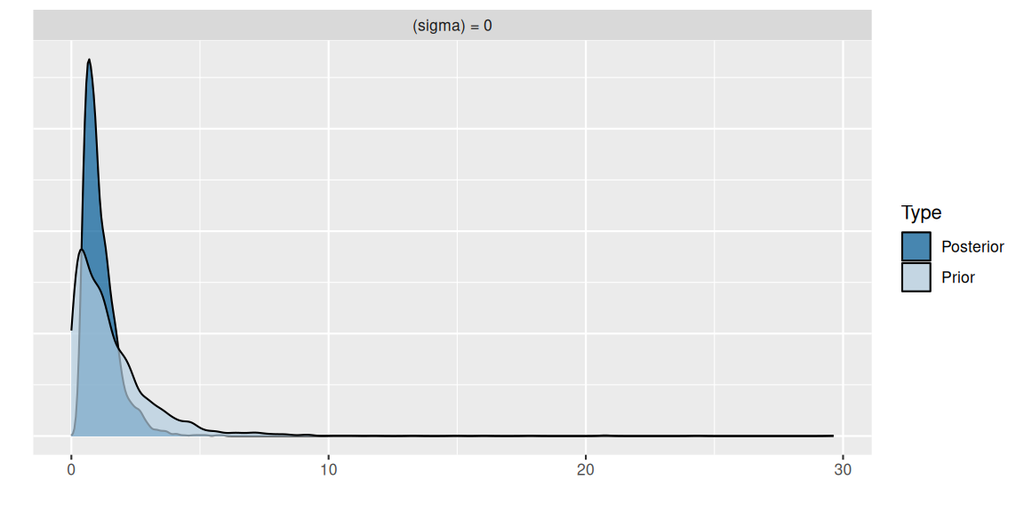

```r
data_gam_brm2 |> hypothesis('sigma = 0', class = '') |> plot()
```

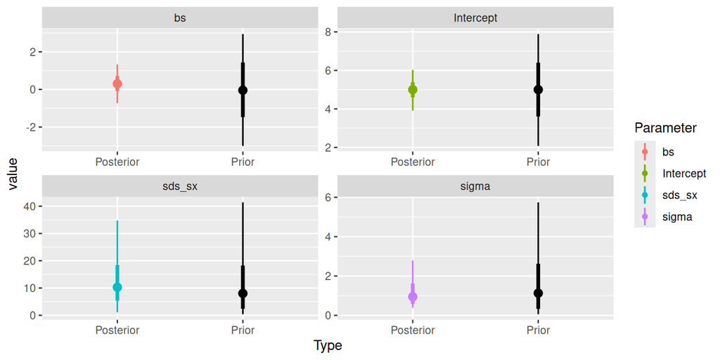

```r
data_gam_brm2 |> SUYR_prior_and_posterior()
```

# 6 MCMC sampling diagnostics

**brms**

**stan plots**

```
'pars' not specified. Showing first 10 parameters by default.
```

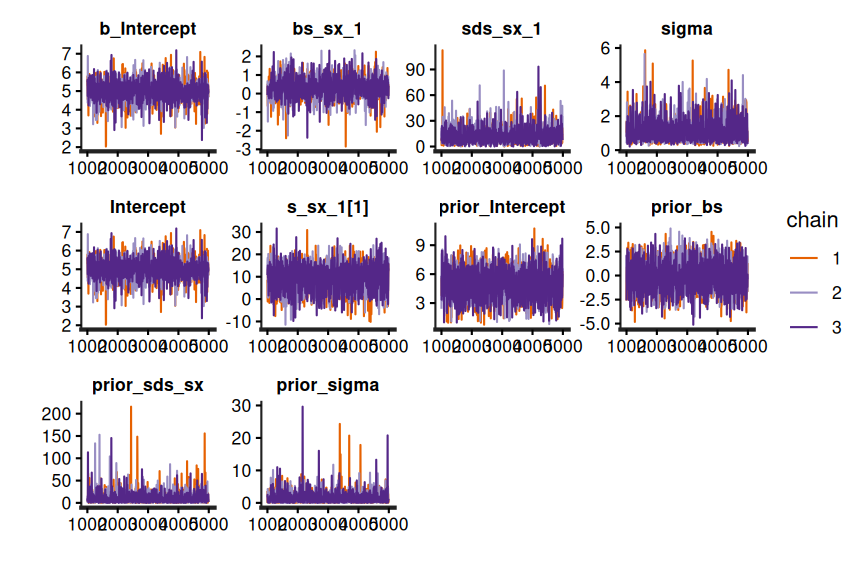

```r
data_gam_brm2$fit |> stan_trace()
```

```
'pars' not specified. Showing first 10 parameters by default.
```

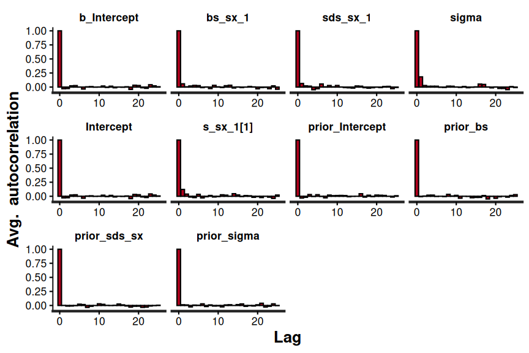

```r
data_gam_brm2$fit |> stan_ac()
```

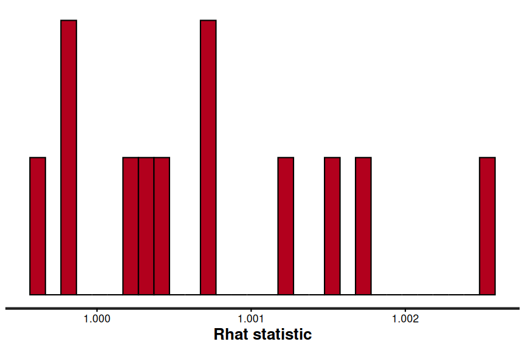

```r
data_gam_brm2$fit |> stan_rhat()
```

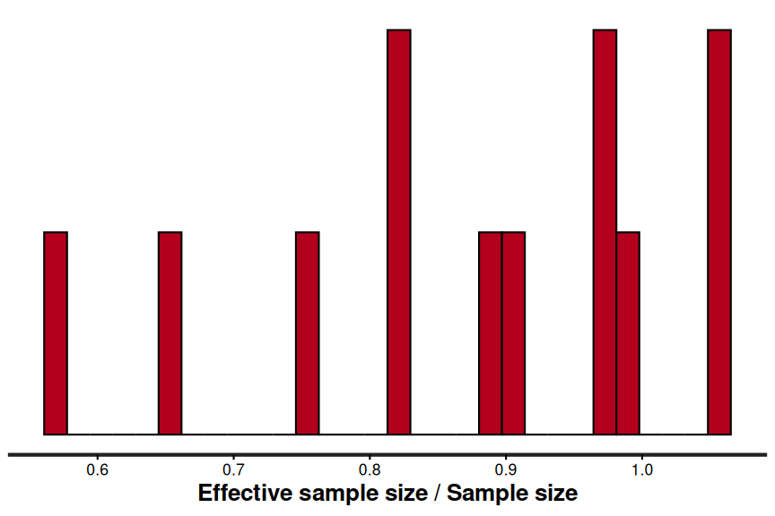

```r
data_gam_brm2$fit |> stan_ess()
```

# 7 Model validation

**brms**

**pp check**

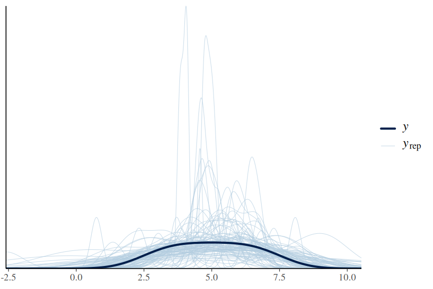

```r
data_gam_brm2 |> pp_check( type='dens_overlay', ndraws=100)
```

**DHARMa residuals**

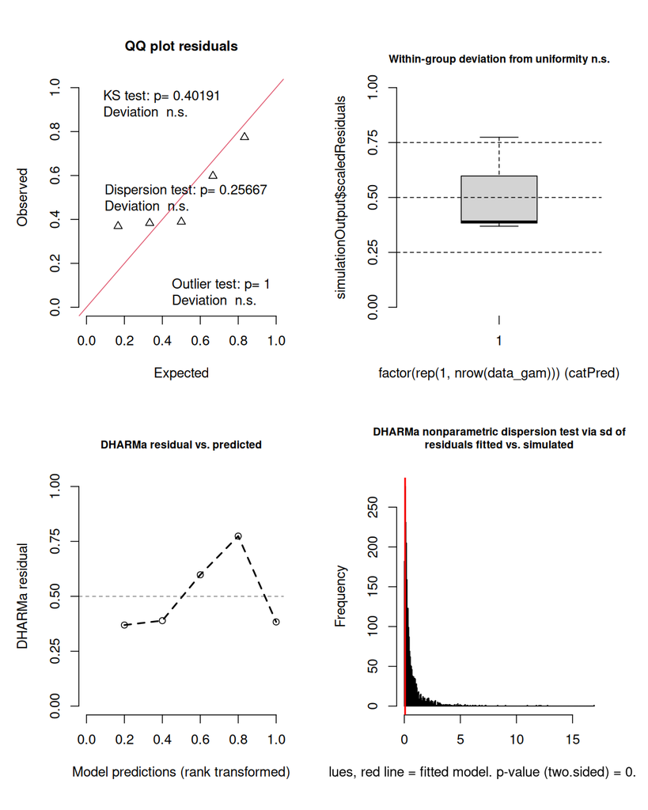

```r
data_gam.resids <- make_brms_dharma_res(data_gam_brm2, integerResponse = FALSE)
wrap_elements(~testUniformity(data_gam.resids)) +
               wrap_elements(~plotResiduals(data_gam.resids, form = factor(rep(1, nrow(data_gam))))) +
               wrap_elements(~plotResiduals(data_gam.resids, quantreg = FALSE)) +
               wrap_elements(~testDispersion(data_gam.resids))
```

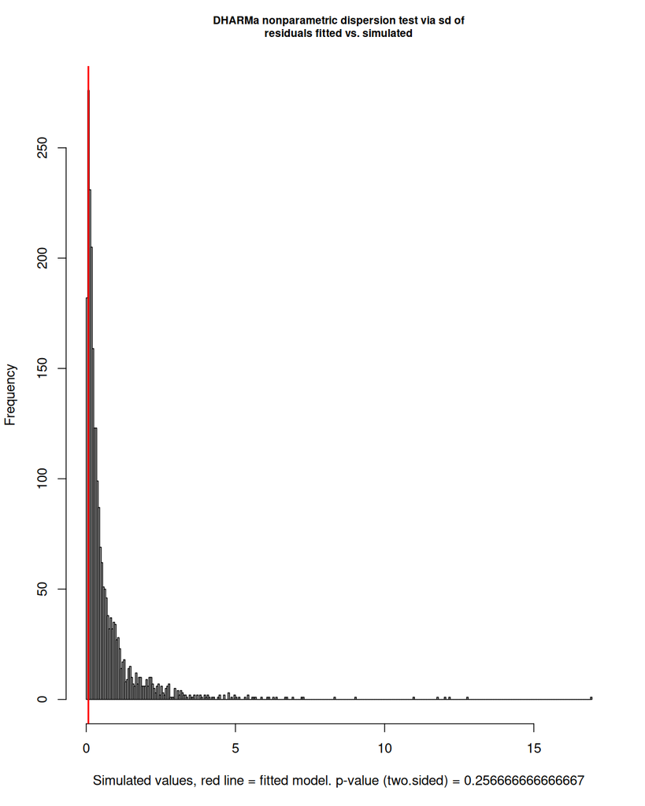

```
    DHARMa nonparametric dispersion test via sd of residuals fitted vs.
    simulated

data:  simulationOutput
dispersion = 0.10835, p-value = 0.2567
alternative hypothesis: two.sided
```

```r
testDispersion(data_gam.resids)
```

# 8 Partial effects plots

**brms**

**conditional_effects**

```
Ignoring unknown labels:
• fill : "NA"
• colour : "NA"
Ignoring unknown labels:
• fill : "NA"
• colour : "NA"
```

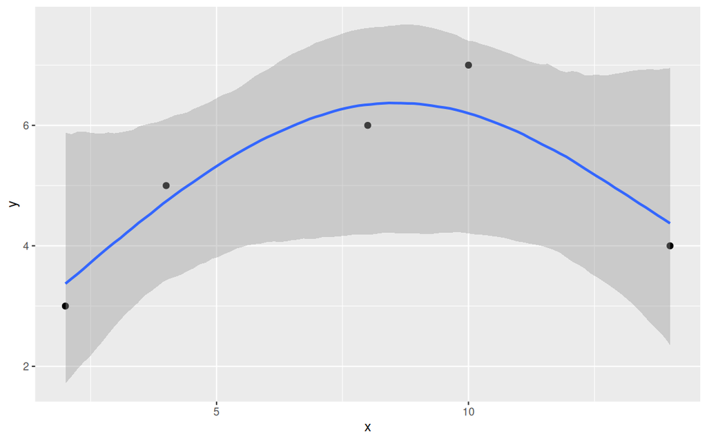

```r
data_gam_brm2 |> conditional_effects() |> plot(points = TRUE)
```

```
Ignoring unknown labels:
• colour : "NA"
Ignoring unknown labels:
• colour : "NA"
```

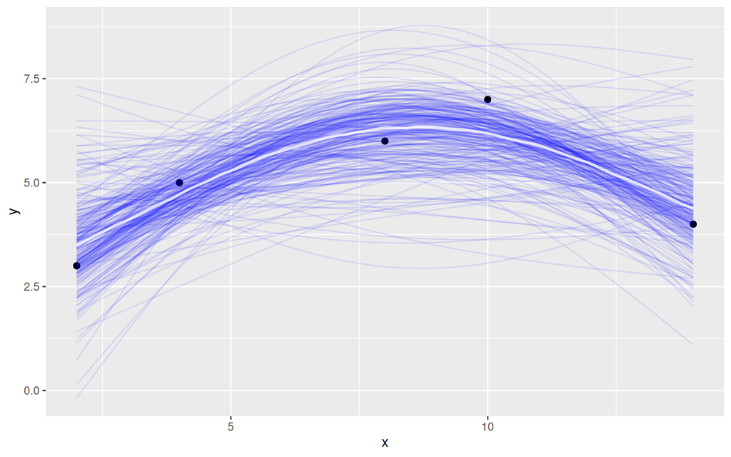

```r
data_gam_brm2 |>
    conditional_effects(spaghetti = TRUE, ndraws = 250) |>
    plot(points = TRUE)
```

# 9 Model investigation

**brms**

**Summary**

```r
data_gam_brm2 |> summary()
```

```
 Family: gaussian
  Links: mu = identity
Formula: y ~ s(x, k = 3)
   Data: data_gam (Number of observations: 5)
  Draws: 3 chains, each with iter = 5000; warmup = 1000; thin = 5;
         total post-warmup draws = 2400

Smoothing Spline Hyperparameters:
          Estimate Est.Error l-95% CI u-95% CI Rhat Bulk_ESS Tail_ESS
sds(sx_1)    12.27      8.94     1.08    34.76 1.00     1864     1933

Regression Coefficients:
          Estimate Est.Error l-95% CI u-95% CI Rhat Bulk_ESS Tail_ESS
Intercept     5.00      0.51     3.91     6.03 1.00     2434     2144
sx_1          0.31      0.51    -0.73     1.33 1.00     1926     2019

Further Distributional Parameters:
      Estimate Est.Error l-95% CI u-95% CI Rhat Bulk_ESS Tail_ESS
sigma     1.12      0.65     0.38     2.79 1.00     1544     2116

Draws were sampled using sampling(NUTS). For each parameter, Bulk_ESS
and Tail_ESS are effective sample size measures, and Rhat is the potential
scale reduction factor on split chains (at convergence, Rhat = 1).
```

- sds(sx_1) is the sd of the smooth weights (spline coefficients). This determines the amount of ‘wiggliness’, in an analogous way to how the sd of group-level effects in a varying slopes and intercepts model determine the amount of variability among groups in slopes and intercepts. However, the actual numeric value of the sds() is not very practically interpretable, because thinking about the variance of smooth weights for any given data and model seems abstract to me. However, if the value is around zero, then this is like ‘complete-pooling’ of the basis functions, which means that there isn’t much added value of more than a single basis function.
- sx_1 is the unpenalized weight (ie coefficient) for one of the “natural” parameterized basis functions. The rest of the basis functions are like varying effects. Again, because the actual numeric value of sxs_1 is the value for the unpenalized coefficient for one of the basis functions, this wouldn’t seem to have a lot of practically interpretable meaning just from viewing this number.

**summarise_draws**

```r
data_gam_brm2 |> get_variables()
```

```
 [1] "b_Intercept"     "bs_sx_1"         "sds_sx_1"        "sigma"
 [5] "Intercept"       "s_sx_1[1]"       "prior_Intercept" "prior_bs"
 [9] "prior_sds_sx"    "prior_sigma"     "lprior"          "lp__"
[13] "accept_stat__"   "stepsize__"      "treedepth__"     "n_leapfrog__"
[17] "divergent__"     "energy__"
```

```r
data_gam_brm2 |>
  as_draws_df() |>
  dplyr::select(matches("^b_.*|^bs.*|^sds.*|^sigma$|^s_s.*")) |>
  summarise_draws(median,
    HDInterval::hdi,
    Pl = ~mean(.x < 0),
    Pg = ~mean(.x > 0)
    )
```

```
# A tibble: 5 × 6
  variable    median    lower upper     Pl    Pg
  <chr>        <dbl>    <dbl> <dbl>  <dbl> <dbl>
1 b_Intercept  5.00   4.01     6.09 0      1
2 bs_sx_1      0.305 -0.735    1.32 0.219  0.781
3 sds_sx_1    10.3    0.00444 27.9  0      1
4 sigma        0.944  0.293    2.44 0      1
5 s_sx_1[1]   10.9   -2.12    19.4  0.0671 0.933
```

# 10 Further analyses

**How much has y increased up to an x value of 9**

```r
newdata <- with(data_gam, data.frame(x = c(min(x), 9)))
add_epred_draws(object = data_gam_brm2, newdata = newdata,
  ndraws =  2400) |>
  ungroup() |>
  group_by(.draw) |>
  summarise(Diff =  diff(.epred)) |>
  summarise(median_hdci(Diff),
    Pl = mean(Diff < 0),
    Pg =  mean(Diff > 0))
```

```
# A tibble: 1 × 8
      y   ymin  ymax .width .point .interval     Pl    Pg
  <dbl>  <dbl> <dbl>  <dbl> <chr>  <chr>      <dbl> <dbl>
1  2.98 -0.329  5.65   0.95 median hdci      0.0529 0.947
```

**find the optimum**

**derivatives**

```r
newdata <- with(data_gam, data.frame(x = seq(min(x), max(x), length = 1000)))
data_gam.peak <-
  add_epred_draws(object = data_gam_brm2, newdata = newdata, ndraws = 1000) |>
  ungroup() |>
  group_by(.draw) |>
   #summarise(x = x[which.max(.epred)]) |>
  mutate(diff = .epred - lag(.epred)) |>
  summarise(x = x[which.min(abs(diff))]) |>
  median_hdci(x, .width = 0.95)
data_gam.peak
```

```
# A tibble: 1 × 6
      x .lower .upper .width .point .interval
  <dbl>  <dbl>  <dbl>  <dbl> <chr>  <chr>
1  8.57   6.15     14   0.95 median hdci
```

```r
## lets plot this
data_gam.preds <-
  data_gam_brm2 |>
  add_epred_draws(newdata = newdata, object = _) |>
  ungroup() |>
  dplyr::select(-.row, -.chain, -.iteration) |>
  group_by(x) |>
  summarise_draws(median, HDInterval::hdi) |>
  ungroup() |>
  mutate(Flag = between(x, data_gam.peak$.lower, data_gam.peak$.upper),
    Grp = data.table::rleid(Flag)
    )
data_gam.preds |> head()
```

```
# A tibble: 6 × 7
      x variable median lower upper Flag    Grp
  <dbl> <chr>     <dbl> <dbl> <dbl> <lgl> <int>
1  2    .epred     3.37  1.66  5.81 FALSE     1
2  2.01 .epred     3.38  1.67  5.81 FALSE     1
3  2.02 .epred     3.39  1.69  5.81 FALSE     1
4  2.04 .epred     3.40  1.72  5.83 FALSE     1
5  2.05 .epred     3.41  1.74  5.83 FALSE     1
6  2.06 .epred     3.42  1.76  5.83 FALSE     1
```

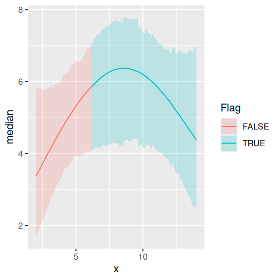

```r
ggplot(data_gam.preds, aes(y = median, x = x)) +
  geom_line(aes(colour = Flag, group = Grp))+
  geom_ribbon(aes(ymin = lower, ymax = upper, fill = Flag, group = Grp), alpha = 0.2)
```

**easystats**

Unfortunately, it does not appear that this option provides confidence intervals.

```r
## data_gam_brm2 |>
##   estimate_relation(keep_iterations = TRUE, length = 1000) |>
##   estimate_smooth(x = "x")
```

**find the largest positive slope**

```r
newdata <- with(data_gam, data.frame(x = seq(min(x), max(x), length = 1000)))
data_gam_brm2 |>
  add_epred_draws(newdata = newdata, object = _) |>
  ungroup() |>
  group_by(.draw) |>
  mutate(diff = .epred - lag(.epred)) |>
  summarise(
    maxGrad = max(abs(diff), na.rm = TRUE),
    x = x[which.max(diff)]) |>
  summarise_draws(median, HDInterval::hdi)
```

```
# A tibble: 2 × 4
  variable  median    lower   upper
  <chr>      <dbl>    <dbl>   <dbl>
1 maxGrad  0.00882 0.000674  0.0140
2 x        2.01    2.01     14
```

**find the greatest change in curvature**

```r
newdata <- with(data_gam, data.frame(x = seq(min(x), max(x), length = 1000)))
data_gam_brm2 |>
  add_epred_draws(newdata = newdata, object = _) |>
  filter(x > 3, x <13) |>
  ungroup() |>
  group_by(.draw) |>
  mutate(diff = .epred - lag(.epred),
    diff2 = diff - lag(diff)) |>
  summarise(
    maxChange = max(abs(diff2), na.rm = TRUE),
    x = x[which.max(diff)]) |>
  summarise_draws(median, HDInterval::hdi)
```

```
# A tibble: 2 × 4
  variable     median         lower      upper
  <chr>         <dbl>         <dbl>      <dbl>
1 maxChange 0.0000262 0.00000000942  0.0000424
2 x         3.02      3.02          13.0
```

# 11 Gaussian Process

**Define priors**

The default priors are generated according to:

```r
x <- data_gam$x
# Pairwise Euclidean distances
dx <- as.numeric(dist(x))
# gp(..., scale = TRUE) rescales distances so that
# the maximum distance is one
dx_scaled <- dx / max(dx)
dmin <- min(dx_scaled[dx_scaled > 0])
dmax <- max(dx_scaled)
# Ratio that the inverse-gamma quantiles must satisfy
target_ratio <- dmax / dmin
shape_equation <- function(shape) {
  qgamma(0.99, shape = shape, rate = 1) /
    qgamma(0.01, shape = shape, rate = 1) -
    target_ratio
}
alpha <- uniroot(
  shape_equation,
  interval = c(0.01, 1000)
)$root
alpha
```

```
[1] 7.301247
```

```r
beta <- dmin * qgamma(
  0.99,
  shape = alpha,
  rate = 1
)
beta
```

```
[1] 2.500722
```

```r
beta <- dmin * qgamma(
  0.99,
  shape = alpha,
  rate = 1
)

beta
```

```
[1] 2.500722
```

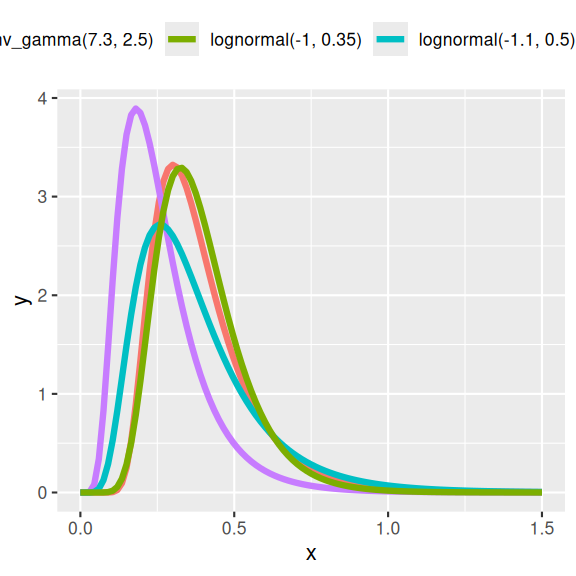

```r
standist::visualize("inv_gamma(7.3, 2.5)",
  "lognormal(-1.46, 0.5)",
  "lognormal(-1.1, 0.5)",
  "lognormal(-1, 0.35)",
  xlim = c(0, 1.5)
)
```

Recommended rule of thumb

For any predictor scaled to range from 0 to 1:

Decide what fraction of the observed range represents the distance beyond which observations should be only weakly related. Define “weakly related” as correlation 0.10. Divide that distance by approximately 2.15. Thus:

$$\boxed{ \text{lscale} \approx \frac{\text{distance where correlation becomes weak}}{2.15} }$$

- Weak correlation after 25% of range: lscale ≈ 0.25 / 2.15 = 0.12
- Weak correlation after 50% of range: lscale ≈ 0.50 / 2.15 = 0.23
- Weak correlation after 75% of range: lscale ≈ 0.75 / 2.15 = 0.35
- Weak correlation after 100% of range: lscale ≈ 1.00 / 2.15 = 0.47

Choosing the sd on lognormal

Here is a useful guide:

| Log-scale SD | Approximate 95% multiplicative range | If median is 0.23 |
| --- | --- | --- |
| 0.20 | divide/multiply by 1.48 | 0.155 to 0.341 |
| 0.25 | divide/multiply by 1.63 | 0.141 to 0.375 |
| 0.35 | divide/multiply by 1.99 | 0.116 to 0.458 |
| 0.50 | divide/multiply by 2.66 | 0.086 to 0.613 |
| 0.70 | divide/multiply by 3.94 | 0.058 to 0.906 |
| 1.00 | divide/multiply by 7.10 | 0.032 to 1.633 |

Thus:

- 0.2 to 0.35 represents fairly strong prior knowledge
- 0.5 represents moderate uncertainty
- 0.7 allows considerable uncertainty
- 1.0 is very broad and allows extremely small and large length scales

```r
data_gam_form <- bf(y ~ gp(x), family = gaussian())
get_prior(data_gam_form, data = data_gam)
```

```
                        prior     class coef group resp dpar nlpar lb ub tag
         student_t(3, 5, 2.5) Intercept
                       (flat)    lscale                             0
 inv_gamma(7.301236, 2.50072)    lscale  gpx                        0
         student_t(3, 0, 2.5)      sdgp                             0
         student_t(3, 0, 2.5)      sdgp  gpx                        0
         student_t(3, 0, 2.5)     sigma                             0
       source
      default
      default
      default
      default
 (vectorized)
      default
```

```r
data_gam |>
  summarise(
    median = median(y),
    mad = mad(y)
    )
```

```
# A tibble: 1 × 2
  median   mad
   <dbl> <dbl>
1      5  1.48
```

```r
priors <-
  ## prior(normal(3, 1.5),  class='Intercept') +
  prior(normal(5, 1.5),  class='Intercept') +
  prior(lognormal(log(0.23), 0.35), class='lscale', coef = "gpx") +  ##log(4/12)
   ## prior(inv_gamma(7, 2.5), class='lscale', coef = "gpx") +
  prior(student_t(3, 0, 1.5),  class='sigma') +
  prior(student_t(3, 0, 1.5), class =  "sdgp")


data_gam_brm3 <- brm(data_gam_form,
  data = data_gam,
  prior = priors,
  sample_prior = 'only',
  iter = 5000,
  warmup = 1000,
  chains = 3, cores =  3,
  thin = 5,
  backend = "rstan",
  control =  list(adapt_delta =  0.99),
  seed = 123,
  refresh = 0)
```

```
Ignoring unknown labels:
• fill : "NA"
• colour : "NA"
Ignoring unknown labels:
• fill : "NA"
• colour : "NA"
```

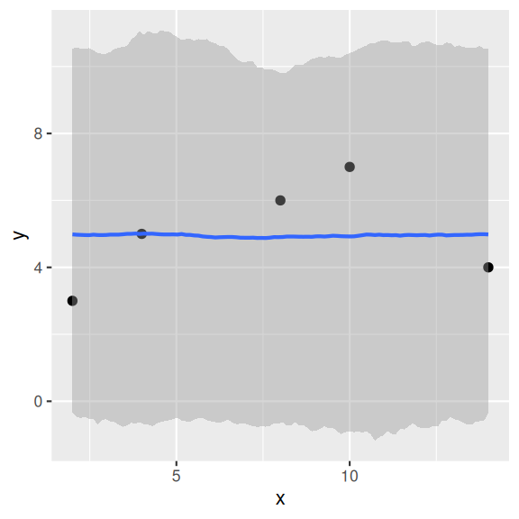

```r
data_gam_brm3 |> conditional_effects() |>  plot(points=TRUE)
```

**Update model**

```r
data_gam_brm4 <- update(data_gam_brm3,
  sample_prior = "yes",
  cores = 3, refresh = 0,
  seed = 123
)
```

```
The desired updates require recompiling the model
```

```
Ignoring unknown labels:
• fill : "NA"
• colour : "NA"
Ignoring unknown labels:
• fill : "NA"
• colour : "NA"
```

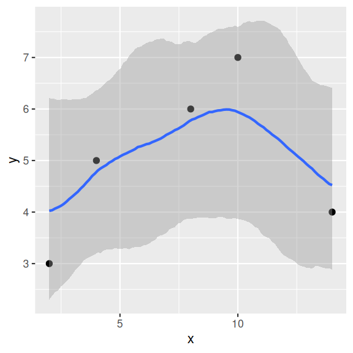

```r
data_gam_brm4 |> conditional_effects() |>  plot(points=TRUE)
```

#### Sample prior and posterior

```r
data_gam_brm4 |> get_variables()
data_gam_brm4 |> hypothesis('sigma = 0', class = '') |> plot()
data_gam_brm4 |>
    as_draws_df(variable = "sdgp", regex = TRUE) |>
    dplyr::select(-.chain, -.iteration, -.draw) |>
    pivot_longer(cols = everything()) |>
  ggplot(aes(x = value, fill = name)) +
  geom_density(alpha = 0.3)
data_gam_brm4 |>
    as_draws_df(variable = "lscale", regex = TRUE) |>
    dplyr::select(-.chain, -.iteration, -.draw) |>
    pivot_longer(cols = everything()) |>
  ggplot(aes(x = value, fill = name)) +
  geom_density(alpha = 0.3)
```

[output not shown]